# (PSL) Hidden Markov Models

```python
import numpy as np
import pandas as pd
import matplotlib.pyplot as plt
from sklearn.preprocessing import normalize
from hmmlearn import hmm
```

# The Dishonest Casino

This example is taken from Durbin et. al. (1999): A dishonest casino uses two dice, one of them is fair the other is loaded.

- State 0: The probabilities of the fair die are (1/6,…,1/6).
- State 1: The probabilities of the loaded die are (1/10,…,1/10,1/2)

The observer doesn’t know which die is actually taken (the state is hidden), but the sequence of throws (observations) can be used to infer which die (state) was used.

```python
# ref https://hmmlearn.readthedocs.io/en/latest/auto_examples/plot_casino.html
gen_model = hmm.CategoricalHMM(n_components=2, random_state=99)
gen_model.startprob_ = np.array([0.5, 0.5])
gen_model.transmat_ = np.array([[0.99, 0.01], [0.02, 0.98]])
gen_model.emissionprob_ = np.array([[1 / 6, 1 / 6, 1 / 6, 1 / 6, 1 / 6, 1 / 6],
                                    [1 / 10, 1 / 10, 1 / 10, 1 / 10, 1 / 10, 1 / 2]])

rolls, gen_states = gen_model.sample(2000)
```

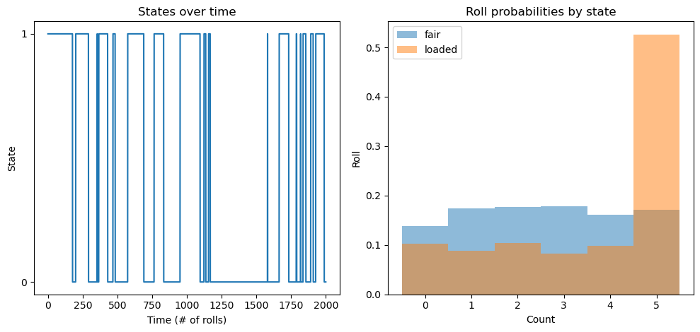

```python
fig, ax = plt.subplots(nrows=1, ncols=2)

# plot states over time, let's just look at the first rolls for clarity
ax[0].plot(gen_states)
ax[0].set_title('States over time')
ax[0].set_yticks([0, 1])
ax[0].set_xlabel('Time (# of rolls)')
ax[0].set_ylabel('State')

# plot rolls for the fair and loaded states
ax[1].hist(rolls[gen_states == 0], label='fair', alpha=0.5,
           bins=np.arange(7) - 0.5, density=True)
ax[1].hist(rolls[gen_states == 1], label='loaded', alpha=0.5,
           bins=np.arange(7) - 0.5, density=True)
ax[1].set_title('Roll probabilities by state')
ax[1].set_xlabel('Count')
ax[1].set_ylabel('Roll')
ax[1].legend()

fig.set_figwidth(10)
fig.tight_layout()
```

# A Simulated Example

Specify the following HMM.

```python
A = np.array([[0.95, 0.05], [0.05,0.95]])
B = np.array([[1/3, 1/3, 1/3], [0.1, 0.2, 0.7]])

gen_model = hmm.CategoricalHMM(n_components=2, random_state=100)
gen_model.startprob_ = np.array([0.5, 0.5])
gen_model.transmat_ = A
gen_model.emissionprob_ = B
```

Generate $n=500$ obs from this HMM.

```python
observations, states = gen_model.sample(500)
```

```python
df = pd.DataFrame({'observations': observations.flatten(), 'states': states}, columns=['observations', 'states'])
df.head()
```

|  | observations | states |
| --- | --- | --- |
| 0 | 1 | 1 |
| 1 | 2 | 1 |
| 2 | 0 | 0 |
| 3 | 2 | 0 |
| 4 | 1 | 0 |

# Fit the data with two hidden states

## Use Baum-Welch (i.e., EM) algorithm to estimate the model parameters.

Note that the algorithm would get stuck, if we initialize the emission distributions to be the same for each latent state.

```python
tmphmm = hmm.CategoricalHMM(n_components=2, random_state=100, n_iter=1000, params='te', init_params='te')
tmphmm.startprob_ = np.array([0.5, 0.5])
tmphmm.fit(observations);
```

```python
print(tmphmm.transmat_)
print(tmphmm.emissionprob_)
```

```
[[0.92500937 0.07499063]
 [0.08759031 0.91240969]]
[[0.05456073 0.15953049 0.78590878]
 [0.3499929  0.30240983 0.34759727]]
```

Next we initilize the emission probability matrix $B$ as follows: generate positive entries for the $2\times 3$ matrix using a gamma distribution, and then divide each entry by the corresponding row sum to ensure each row is a probability vector summing to 1.

```python
tmpB = np.random.default_rng(seed=100).gamma(shape=1, size=(2, 3))
tmpB = normalize(tmpB, axis=1, norm='l1')

myhmm2 = hmm.CategoricalHMM(n_components=2, algorithm='viterbi',
                            random_state=100, n_iter=1000, params='te', init_params='t')
myhmm2.startprob_ = np.array([0.5, 0.5])
myhmm2.emissionprob_ = tmpB
myhmm2.fit(observations);
```

```python
print(myhmm2.transmat_)
print(myhmm2.emissionprob_)
```

```
[[0.93164518 0.06835482]
 [0.0588251  0.9411749 ]]
[[0.34093208 0.29693869 0.36212923]
 [0.06069123 0.16345557 0.7758532 ]]
```

## Predict Latent States using Individual Marginal Probabilities

Compute the (marginal) conditional distribution of the hidden state for each observation: $P(Z_i = k \mid X_1, \dotsc, X_n)$. Then classify $Z_i$ to be the most probable state.

```python
mypost = myhmm2.predict_proba(observations)
```

## Predict Latent States using the Viterbi algorithm

Use the Viterbi algorithm to compute the most probable hidden sequence.

```python
vit_out = myhmm2.predict(observations)
```

## Display the result

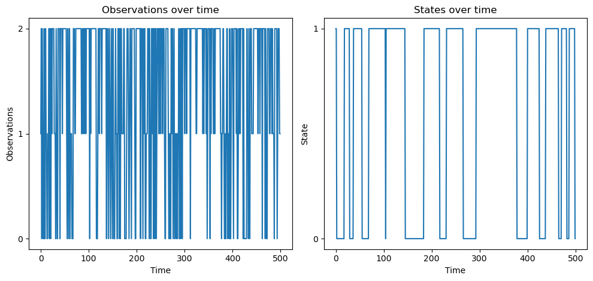

```python
# plot the data and hidden state
fig, ax = plt.subplots(nrows=1, ncols=2)

ax[0].plot(observations)
ax[0].set_title('Observations over time')
ax[0].set_yticks([0, 1, 2])
ax[0].set_xlabel('Time')
ax[0].set_ylabel('Observations')

ax[1].plot(states)
ax[1].set_title('States over time')
ax[1].set_yticks([0, 1])
ax[1].set_xlabel('Time')
ax[1].set_ylabel('State')

fig.set_figwidth(10)
fig.tight_layout()
```

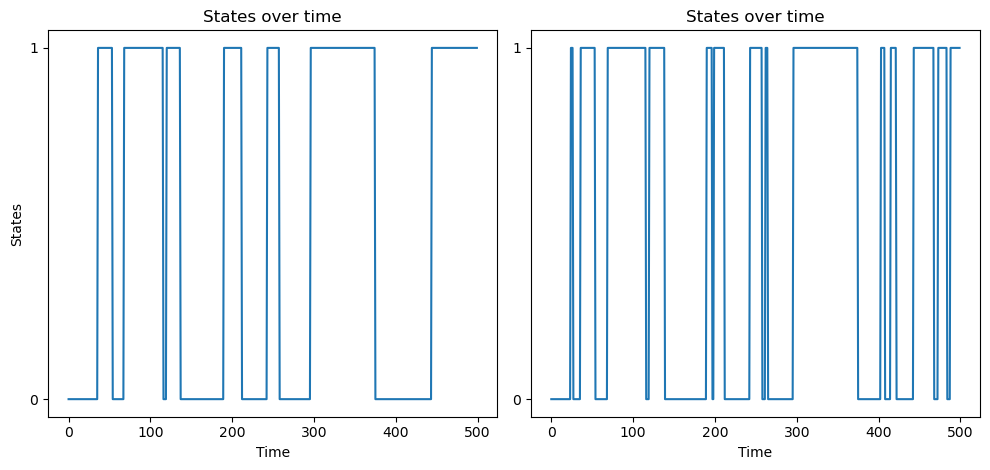

```python
# display the post probable path and the marginal most probable state
# plot the data and hidden state
fig, ax = plt.subplots(nrows=1, ncols=2)

ax[0].plot(vit_out)
ax[0].set_title('States over time')
ax[0].set_yticks([0, 1])
ax[0].set_xlabel('Time')
ax[0].set_ylabel('States')

ax[1].plot(mypost[:, 1] > 0.5)
ax[1].set_title('States over time')
ax[1].set_yticks([0, 1])
ax[1].set_xlabel('Time')
ax[1].set_ylabel('')

fig.set_figwidth(10)
fig.tight_layout()
```

## Fit the data with three hidden states

The number of hidden states is a tuning parameter. We can try a range of hidden states and then use AIC/BIC to select $K$, the number of hidden states.

```python
tmpB = np.random.default_rng(seed=100).gamma(shape=1, size=(3, 3))
tmpB = normalize(tmpB, axis=1, norm='l1')
```

```python
myhmm3 = hmm.CategoricalHMM(n_components=3, algorithm='viterbi', random_state=100, n_iter=1000, params='te', init_params='t')
myhmm3.startprob_ = np.array([1 / 3, 1 / 3, 1 / 3])
myhmm3.emissionprob_ = tmpB
myhmm3.fit(observations);
```

```python
print(myhmm3.transmat_)
print(myhmm3.emissionprob_)
```

```
[[8.18459604e-01 1.81539296e-01 1.09930447e-06]
 [5.78486319e-01 2.38675547e-03 4.19126925e-01]
 [4.04587146e-02 3.56797924e-02 9.23861493e-01]]
[[0.36310054 0.28948349 0.34741597]
 [0.16483973 0.31747015 0.51769012]
 [0.05744807 0.15724733 0.7853046 ]]
```

Note that the likelihood of the data (integrated over all possible hidden sequences) could be computed using the `score` command.

```python
myhmm2.score(observations)
```

```
-467.42287513720316
```

```python
myhmm3.score(observations)
```

```
-467.4674511735908
```

The two log-likelihoods are pretty close, so the model with two hidden states, which uses less number of parameters, will be chosen by AIC or BIC, once we add the penalty for the number of parametres.